# Mini-Project 01 Revised

Krystal Rivera Analysis

# Data Visualization Mini-Project 01 Revised

The revised version of [‘Rivera Mini Project 1’](https://rpubs.com/Krvera7522/913722), was completed to demonstrate the development of skills learned throughout the course, and to put into practice the principles of data visualization explored through different provided materials. The data frame used was “marathon_results_2017.csv”, provided by Professor Rei Sanchez. This data contained information about the finishers of the Boston marathon of 2017.

This data set was selected among a list of 8 possible data frames. I chose this data set to analyze because I love running and I was interested to see the relationships among the variables. I was curious to see the representation among genders, age ranges of the participants, their performance, as well as to learn what were the top five countries participating.

## Loading the data.

```r
library(tidyverse)
library(dplyr)
library(ggplot2)
library(ggtext)
library(grid)

df <- read_csv("https://raw.githubusercontent.com/reisanar/datasets/master/marathon_results_2017.csv", col_types = cols())
```

## Getting Familiar with the data set

```r
# Renaming the M/F column as Sex
colnames(df)[4] <- 'Sex'
colnames(df)[19]<- 'OfficialTime'
df
```

```
## # A tibble: 26,410 x 22
##    Bib   Name    Age Sex   City  State Country `5K`   `10K` `15K` `20K` Half
##    <chr> <chr> <dbl> <chr> <chr> <chr> <chr>   <time> <chr> <chr> <chr> <time>
##  1 11    Kiru~    24 M     Keri~ <NA>  KEN     15'25" 0:30~ 0:45~ 1:01~ 01:04:35
##  2 17    Rupp~    30 M     Port~ OR    USA     15'24" 0:30~ 0:45~ 1:01~ 01:04:35
##  3 23    Osak~    25 M     Mach~ <NA>  JPN     15'25" 0:30~ 0:45~ 1:01~ 01:04:36
##  4 21    Biwo~    32 M     Mamm~ CA    USA     15'25" 0:30~ 0:45~ 1:01~ 01:04:45
##  5 9     Cheb~    31 M     Mara~ <NA>  KEN     15'25" 0:30~ 0:45~ 1:01~ 01:04:35
##  6 15    Abdi~    40 M     Phoe~ AZ    USA     15'25" 0:30~ 0:45~ 1:01~ 01:04:35
##  7 63    Maiy~    33 M     Colo~ CO    USA     15'25" 0:30~ 0:45~ 1:01~ 01:04:36
##  8 7     Sefi~    28 M     Addi~ <NA>  ETH     15'24" 0:30~ 0:46~ 1:02~ 01:06:04
##  9 18    Pusk~    27 M     Euge~ OR    USA     15'24" 0:30~ 0:45~ 1:01~ 01:04:53
## 10 20    Ward~    28 M     Kays~ UT    USA     15'25" 0:30~ 0:45~ 1:01~ 01:04:53
## # ... with 26,400 more rows, and 10 more variables: 25K <time>, 30K <time>,
## #   35K <time>, 40K <time>, Pace <time>, Proj Time <chr>, OfficialTime <time>,
## #   Overall <dbl>, Gender <dbl>, Division <dbl>
```

### 1.What is the proportion of males vs. females runners in the race?

```r
Genders <- df %>%
  group_by(Sex) %>%
  summarize(Total = n(), .groups = 'drop')

str(Genders)
```

```
## tibble [2 x 2] (S3: tbl_df/tbl/data.frame)
##  $ Sex  : chr [1:2] "F" "M"
##  $ Total: int [1:2] 11972 14438
```

Creating the first data visualization:

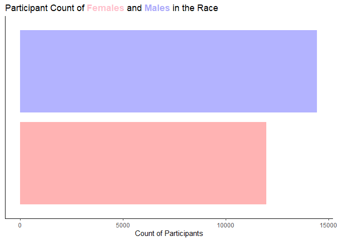

```r
ggplot(Genders, aes(x = Sex,y = Total, fill = Sex)) + geom_col()+
  theme_classic() +

  # Graph Aesthetics
  labs(x = NULL,
    title = "Participant Count of <span style = 'color: pink;'>**Females**</span> and <span style = 'color: #ABA9FA;'>**Males**</span> in the Race", y = 'Count of Participants')+
  scale_fill_manual(values = alpha(c("red", "blue"), .3))+
      theme(plot.title = element_markdown(),axis.text.y=element_blank(), axis.ticks.y=element_blank())+
  theme(legend.position = 'none')+
  coord_flip()+
  ylim(0,14500)
```

### **Findings**

> There is a total of 26,410 participants in the marathon, out of which 11,972 are females and 14438 are males. The marathon is comprised of 45.33% females participants and 54.66% males. One can see from the graph above that there are more males than females.

### 2.What relationships can be found among Sex, Age, and Pace?

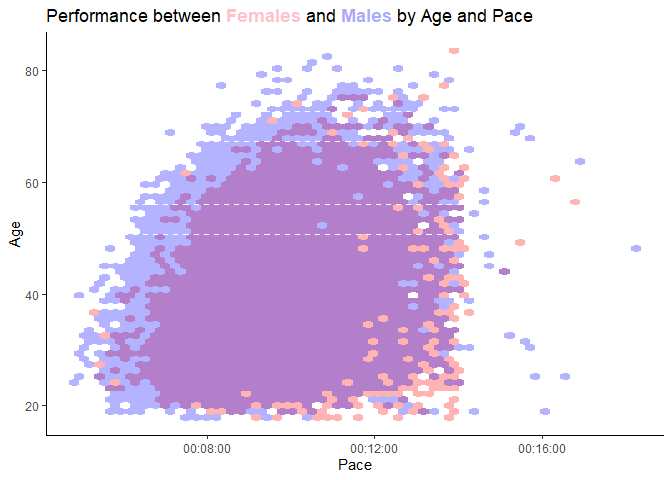

```r
d <- ggplot(df, aes(Pace, Age, fill = Sex))
d + geom_hex(bins = 55)+

# Graph Aesthetics
  theme_classic()+

labs(title = " Performance between <span style = 'color: pink;'>**Females**</span> and <span style = 'color: #ABA9FA;'>**Males**</span> by Age and Pace") +
  theme(plot.title = element_markdown())+
  theme(legend.position = 'none')+
 scale_fill_manual(values = alpha(c("red", "blue"), .3))
```

```r
# Creating Age groups
 df$AGE<-df$Age
 df$AGE[df$AGE<=20]<-"20 and below"
 df$AGE[df$AGE>=21 & df$AGE<=36]<-"21-36"
 df$AGE[df$AGE>=37 & df$AGE<=52]<-"37-52"
 df$AGE[df$AGE>=53 & df$AGE<=68]<-"53-68"
 df$AGE[df$AGE>=69 & df$AGE<=79]<-"69-79"
 df$AGE[df$AGE>=80]<-"80+"
```

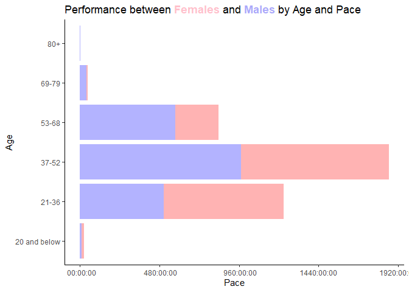

```r
ggplot(df, aes(x = AGE,y = Pace, fill = Sex)) + geom_col()+
  theme_classic() +
  labs(title = "Performance between <span style = 'color: pink;'>**Females**</span> and <span style = 'color: #ABA9FA;'>**Males**</span> by Age and Pace", y = 'Pace', x = 'Age')+
  coord_flip()+
  scale_fill_manual(values = alpha(c("red", "blue"), .3))+
  theme(plot.title = element_markdown(), legend.position = 'none')
```

### 3. What is the age distribution among the participants?

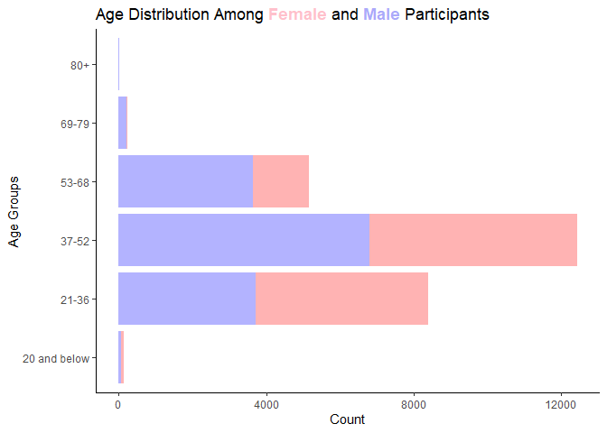

```r
ggplot(data = df) +
  geom_bar(mapping = aes(x = AGE,
                         fill= Sex))+

labs(title = "Age Distribution Among <span style = 'color: pink;'>**Female**</span> and <span style = 'color: #ABA9FA;'>**Male**</span> Participants", y = 'Count', x = 'Age Groups')+
  scale_fill_manual(values = alpha(c("red", "blue"), .3))+
  coord_flip()+
  theme_classic()+
  theme(plot.title = element_markdown(), legend.position = 'none')
```